# Machine Learning Example

Christoph Kern

## Setup

```r
library(tidyverse)
library(caret)
library(rpart)
library(ranger)
library(pROC)
```

## Data

For this example, we use the census income data set from the UCI ML repository. It contains “a set of reasonably clean records” from the 1994 Census database. The prediction task is to determine whether a person makes over 50K a year.

Source: https://archive.ics.uci.edu/ml/datasets/Census+Income

First, we load the data and assign variable names.

```r
census <- read.csv("census.data", header = FALSE, na.strings = " ?")
varnames <- read.delim("census.names", header = FALSE, skip = 95)
names(census) <- as.character(varnames$V1)
```

Next, we have to clean the factor levels.

```r
cln_levels <- function(x){
  levels(x) <- make.names(gsub(" ", "", levels(x)))
  x
}
census[, c(2,4,6,7,8,9,14)] <- lapply(census[, c(2,4,6,7,8,9,14)], cln_levels)
```

In addition, we drop cases with missing values and empty factor levels.

```r
census$capital_gain[census$capital_gain >= 99990] <- NA
census <- drop_na(census)
census <- droplevels(census)
```

We also exclude some variables that we won’t use in our models.

```r
census$fnlwgt <- NULL # Survey weight
census$education <- NULL # We have education_num
census$native_country <- NULL # Rare categories
```

Here we rename the factor levels of the outcome variable and print the frequencies of the outcome categories.

```r
levels(census$inc) <- c("under_50K", "over_50K")
summary(census$inc)
```

```
under_50K  over_50K
    22654      7360
```

## Train and test set

Next, we want to split the data into a training (80%) and a test (20%) set. We use `createDataPartition()` from `caret` for this task, which samples within the levels of the outcome variable when splitting the data (i.e. creates stratified splits).

```r
set.seed(92385)
inTrain <- createDataPartition(census$inc,
                               p = .8,
                               list = FALSE,
                               times = 1)
census_train <- census[inTrain,]
census_test <- census[-inTrain,]
```

## CART

With the caret package, we first prepare a helper object via `trainControl()`, which allows us to select the desired evaluation method.

```r
ctrl <- trainControl(method = "cv",
                      number = 10,
                      summaryFunction = twoClassSummary,
                      verboseIter = TRUE,
                      classProbs = TRUE)
```

We can now train and tune decision trees with `train()`.

```r
cart <- train(inc ~ .,
              data = census_train,
              method = "rpart2",
              trControl = ctrl,
              metric = "ROC")
```

Print the tuning results.

```r
cart
```

```
CART

24012 samples
   11 predictors
    2 classes: 'under_50K', 'over_50K'

No pre-processing
Resampling: Cross-Validated (10 fold)
Summary of sample sizes: 21611, 21611, 21611, 21610, 21610, 21611, ...
Resampling results across tuning parameters:

  maxdepth  ROC        Sens       Spec
  2         0.8029006  0.9508936  0.4009895
  3         0.8151467  0.9503969  0.4660363
  4         0.8396192  0.9499555  0.5032313

ROC was used to select the optimal model using the largest value.
The final value used for the model was maxdepth = 4.
```

## Random Forests

Next, we use the `caret` package for training random forests. For this, we specify our own tuning grid. We consider two settings for `mtry` and specify the tree building methods via `splitrule`.

```r
grid <- expand.grid(mtry = c(round(sqrt(ncol(census_train))),
                             round(log(ncol(census_train)))),
                    splitrule = c("gini", "extratrees"),
                    min.node.size = 10)
grid
```

| mtry | splitrule | min.node.size |
| --- | --- | --- |
| 3 | gini | 10 |
| 2 | gini | 10 |
| 3 | extratrees | 10 |
| 2 | extratrees | 10 |

Start the tuning process.

```r
set.seed(87543)
rf <- train(inc ~ .,
            data = census_train,
            method = "ranger",
            trControl = ctrl,
            tuneGrid = grid,
            metric = "ROC")
```

List the tuning results.

```r
rf
```

```
Random Forest

24012 samples
   11 predictors
    2 classes: 'under_50K', 'over_50K'

No pre-processing
Resampling: Cross-Validated (10 fold)
Summary of sample sizes: 21611, 21611, 21610, 21611, 21611, 21611, ...
Resampling results across tuning parameters:

  mtry  splitrule   ROC        Sens       Spec
  2     gini        0.9084271  0.9710324  0.4677292
  2     extratrees  0.8889840  0.9700391  0.3780569
  3     gini        0.9135884  0.9527695  0.5631772
  3     extratrees  0.8960523  0.9414588  0.5156246

Tuning parameter 'min.node.size' was held constant at a value of 10
ROC was used to select the optimal model using the largest value.
The final values used for the model were mtry = 3, splitrule =
 gini and min.node.size = 10.
```

## Prediction performance

In order to evaluate the performance of the (best) decision tree and random forest, we first compute predicted probabilities and class predictions in the test set.

```r
cart_p <- predict(cart, newdata = census_test, type = "prob")
cart_c <- predict(cart, newdata = census_test)

rf_p <- predict(rf, newdata = census_test, type = "prob")
rf_c <- predict(rf, newdata = census_test)
```

The `roc()` function allows us to compute ROC curves and ROC-AUCs.

```r
cart_roc <- roc(census_test$inc, cart_p$over_50K)
cart_roc
rf_roc <- roc(census_test$inc, rf_p$over_50K)
rf_roc
```

[output not shown]

The resulting object can be plotted with `ggroc()`.

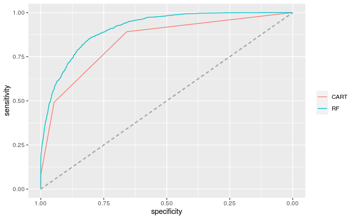

```r
ggroc(list(CART = cart_roc,
           RF = rf_roc)) +
  geom_segment(aes(x = 1, xend = 0, y = 0, yend = 1),
               color="darkgrey", linetype="dashed") +
  theme(legend.title = element_blank())
```

In addition, we can inspect the prediction performance using `confusionMatrix()`, which can be used to display a lot of performance measures, given predicted classes.

```r
confusionMatrix(cart_c, census_test$inc, mode = "everything", positive = "over_50K")
```

```
Confusion Matrix and Statistics

           Reference
Prediction  under_50K over_50K
  under_50K      4290      748
  over_50K        240      724

               Accuracy : 0.8354
                 95% CI : (0.8258, 0.8447)
    No Information Rate : 0.7547
    P-Value [Acc > NIR] : < 2.2e-16

                  Kappa : 0.4967

 Mcnemar's Test P-Value : < 2.2e-16

            Sensitivity : 0.4918
            Specificity : 0.9470
         Pos Pred Value : 0.7510
         Neg Pred Value : 0.8515
              Precision : 0.7510
                 Recall : 0.4918
                     F1 : 0.5944
             Prevalence : 0.2453
         Detection Rate : 0.1206
   Detection Prevalence : 0.1606
      Balanced Accuracy : 0.7194

       'Positive' Class : over_50K
```

```r
confusionMatrix(rf_c, census_test$inc, mode = "everything", positive = "over_50K")
```

```
Confusion Matrix and Statistics

           Reference
Prediction  under_50K over_50K
  under_50K      4301      648
  over_50K        229      824

               Accuracy : 0.8539
                 95% CI : (0.8447, 0.8627)
    No Information Rate : 0.7547
    P-Value [Acc > NIR] : < 2.2e-16

                  Kappa : 0.5634

 Mcnemar's Test P-Value : < 2.2e-16

            Sensitivity : 0.5598
            Specificity : 0.9494
         Pos Pred Value : 0.7825
         Neg Pred Value : 0.8691
              Precision : 0.7825
                 Recall : 0.5598
                     F1 : 0.6527
             Prevalence : 0.2453
         Detection Rate : 0.1373
   Detection Prevalence : 0.1754
      Balanced Accuracy : 0.7546

       'Positive' Class : over_50K
```